# QAPA + goseq demo

Chi Lam Poon

11/22/2019

### Materials

QAPA: RNA-seq Quantification of Alternative Polyadenylation

See their [github](https://github.com/morrislab/qapa) and follow their instruction step by step.

HNSC data:

1. SRR5528013 (DMSO)
2. SRR5528014 (Aza/TSA)

> Note that the latest version of Salmon (v1.0.0) has bug for 3’UTR fasta indexing, therefore remember to use Salmon v0.15 for this step before they fix it!

### Prepare QAPA

#### Retrive gene annotation from biomart

```r
library("biomaRt")
ensembl <- useMart("ensembl", dataset="hsapiens_gene_ensembl")
geneList <- getBM(mart=ensembl,
                  attributes=c("ensembl_gene_id",
                               "ensembl_transcript_id",
                               "gene_biotype",
                               "transcript_biotype",
                               "external_gene_name"))

colnames(geneList) <- c("Gene stable ID", "Transcript stable ID", "Gene type", "Transcript type", "Gene name")
write.table(geneList, file="~/APA/qapa/ensembl_identifiers.txt", quote = F, row.names = F, sep = "\t")
```

```bash
conda install salmon=0.15
qapa fasta -f ../utr/genome/hg38/hg38.fa ../qapa/qapa_3utrs.gencode_V31.hg38.bed output_sequences.fa
./utr.quant.sh
qapa quant --db ../qapa/ensembl_identifiers.txt quants/SRR*/quant.sf > pau.results.txt
```

`utr.quant.sh`:

```bash
#!/bin/bash

echo "Quantifying UTR isoform expression..."
for fn in ~/APA/utr/data/SRR55280{13..14};
do
  samp=`basename ${fn}`
  echo "Processing sample ${samp}"
  salmon quant -i utr_library/ -l A -r ${fn}.fastq -p 8 --validateMappings -o quants/${samp}
done
```

### Get results

```r
pau.res <- read.delim(file = '~/APA/res.qapa/pau.results.txt', header = T)
head(pau.res)
```

```
##                APA_ID      Transcript            Gene Gene_Name   Chr
## 1 ENSG00000004059_1_S ENST00000000233 ENSG00000004059      ARF5  chr7
## 2 ENSG00000003056_1_D ENST00000000412 ENSG00000003056      M6PR chr12
## 3 ENSG00000003056_2_D ENST00000000412 ENSG00000003056      M6PR chr12
## 4 ENSG00000003056_3_P ENST00000000412 ENSG00000003056      M6PR chr12
## 5 ENSG00000173153_1_S ENST00000000442 ENSG00000173153     ESRRA chr11
## 6 ENSG00000004478_1_P ENST00000001008 ENSG00000004478     FKBP4 chr12
##   LastExon.Start LastExon.End Strand UTR3.Start  UTR3.End Length
## 1      127591212    127591705      +  127591299 127591705    406
## 2        8940341      8941940      -    8940341   8941817   1476
## 3        8941405      8941940      -    8941405   8941817    412
## 4        8941642      8941940      -    8941642   8941817    175
## 5       64315706     64316743      +   64315966  64316743    777
## 6        2803150      2803351      +    2803258   2803351     93
##   Num_Events SRR5528013.PAU SRR5528014.PAU SRR5528013.TPM SRR5528014.TPM
## 1          1        100.000        100.000      86.802775      59.775452
## 2          3         19.377         14.915      12.950838      16.905527
## 3          3          0.000          0.000       0.000000       0.000000
## 4          3         80.623         85.085      53.885553      96.441717
## 5          1        100.000        100.000       7.536465       7.174089
## 6          7         94.711         96.400     240.763842     357.247193
```

```r
nrow(pau.res)
```

```
## [1] 41857
```

### Analyze QAPA results

#### Filtering

1. Keep 3’UTR that had a total gene expression of at least 3 TPM for both samples **(should be aggregate to gene-level first…)**
2. Exclude gene pairs whose distal 3’UTRs had 3’ ends that were within 500 nt of each other
3. Exclude genes with a aUTR lengths of less than 100 nt to reduce potentially noisy estimates

```r
# 1. filt by TPM > 3 (improve later)
tpm.header <- grep("TPM", colnames(pau.res))
pau.res$total.tpm <- apply(pau.res[ ,tpm.header], 1, sum)

gene.split <- split(pau.res$total.tpm, as.character(pau.res$Gene))
keep.list <- gene.split[lapply(gene.split, sum) > 3]
length(keep.list)
```

```
## [1] 9011
```

```r
filt.res <- pau.res[pau.res$Gene %in% names(keep.list), ]
filt.res <- filt.res[,-ncol(filt.res)]
nrow(filt.res)
```

```
## [1] 27729
```

```r
# 2. filt by 3'end position
suppressPackageStartupMessages(library(doParallel))
registerDoParallel()

filt.res <- filt.res[order(filt.res$Gene),]
distal.df <- filt.res[grep("_D$", filt.res$APA_ID),]
dis.gene <- unique(as.character(distal.df$Gene))
distal.end <- foreach(gene=dis.gene, .combine = c) %dopar% {
  trsc <- distal.df[distal.df$Gene == gene,]
  strand <- as.character(unique(trsc$Strand))
  if (strand == "+") {
    maxD <- trsc$UTR3.End
  } else {
    maxD <- trsc$UTR3.Start
  }
  maxD
}

end.df <- data.frame(id=distal.df$Gene, end=distal.end)
end.df$id <- as.character(end.df$id)

throw.id <- foreach(g=1:(length(dis.gene)-1), .combine = c) %dopar% {
  gene <- dis.gene[g]
  range <- c()
  for (i in end.df[end.df$id==gene, ]$end) {
    range <- c(range, seq(i-500, i+500, by=1))
  }
  # sweep the window
  trap <- foreach(k=(g+1):length(dis.gene), .combine = c) %do% {
    if (any(end.df[end.df$id==dis.gene[k], ]$end %in% range)) dis.gene[k]
  }
  if (is.null(trap)) {
    final <- c()
  } else {
    final <- c(gene, trap)
  }
  final
}

length(throw.id)
```

```
## [1] 772
```

```r
filt.res2 <- filt.res[!filt.res$Gene %in% throw.id, ]
nrow(filt.res2)
```

```
## [1] 24319
```

```r
# 3. filt by aUTR length
# aUTR = farthest dPAS - pPAS
#      = max(UTR length) - min(UTR length)

utr.split <- split(filt.res2$Length, as.character(filt.res2$Gene))
deltaUTR <- function(vec) {
  max(vec) - min(vec)
}
long.utr <- utr.split[lapply(utr.split, deltaUTR) > 100]
filt.res3 <- filt.res2[filt.res2$Gene %in% names(long.utr), ]
nrow(filt.res3)
```

```
## [1] 20243
```

```r
## save filtered QAPA result
saveRDS(filt.res3, file='~/APA/res.qapa/qapa.filt.res.rds')
```

#### Calculate PPAU

delta PPAU: change in pPAS usage, if replicates, use median

However actually many changes happened in various distal PAS, so…?

- lengthening: delta PPAU > 20
- no change: delta PPAU %in% -20 ~ 20
- shortening: delta PPAU < -20

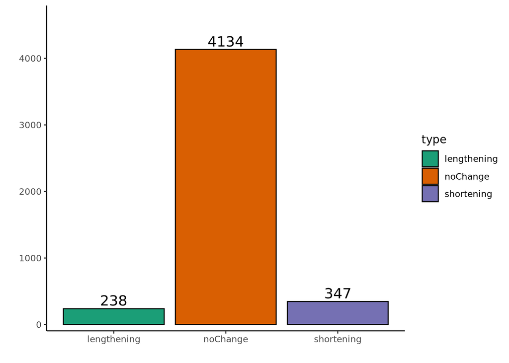

```r
ppas <- filt.res3[grep("_P$", filt.res3$APA_ID), ]
# delta PPAU = ctrl PAU - case PAU
ppas$ppau <- ppas$SRR5528014.PAU - ppas$SRR5528013.PAU

type.list <- list()
type.list[['shortening']] <- filt.res3[filt.res3$Gene %in% as.character(ppas[ppas$ppau <= -20, ]$Gene),]
type.list[['noChange']] <- filt.res3[filt.res3$Gene %in% as.character(ppas[ppas$ppau > -20 & ppas$ppau < 20, ]$Gene),]
type.list[['lengthening']] <- filt.res3[filt.res3$Gene %in% as.character(ppas[ppas$ppau >= 20, ]$Gene),]

# bar plot
ppau.sum <- data.frame(cnt = as.integer(lapply(type.list, function(x) length(unique(x$Gene)))),
                       type = names(type.list))

suppressPackageStartupMessages(library(ggplot2))

ggplot(ppau.sum, aes(x=type, y=cnt, fill=type)) +
  geom_bar(stat = "identity", color="black") +
  scale_y_continuous(limits=c(0,4700), expand = c(0.02,0)) +
  geom_text(aes(type, cnt, label = cnt), size=5, vjust=-0.3, hjust=0.5) +
  scale_fill_brewer(palette='Dark2') +
  labs(x="", y="") +
  theme_classic()
```

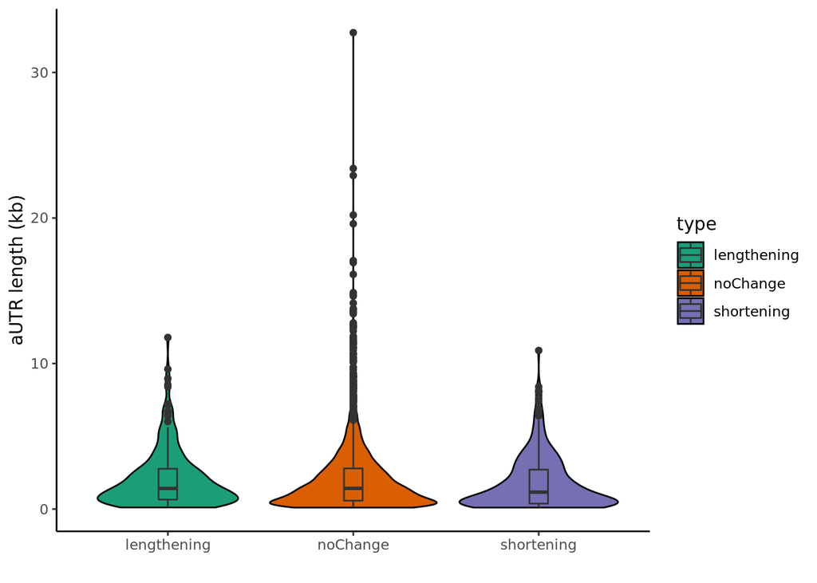

```r
# violin plot
autr.df <- data.frame()
for (type in names(type.list)) {
  df <- type.list[[type]]
  tmp <- split(df$Length, as.character(df$Gene))
  aUTR <- data.frame(length=sapply(tmp, deltaUTR))
  aUTR$type <- type
  autr.df <- rbind(autr.df, aUTR)
}
autr.df$length <- autr.df$length/1000

ggplot(autr.df, aes(x=type, y=length, fill=type)) +
  geom_violin(color="black") +
  geom_boxplot(width=0.1) +
  scale_fill_brewer(palette='Dark2') +
  labs(x="", y="aUTR length (kb)") +
  theme_classic()
```

#### Density

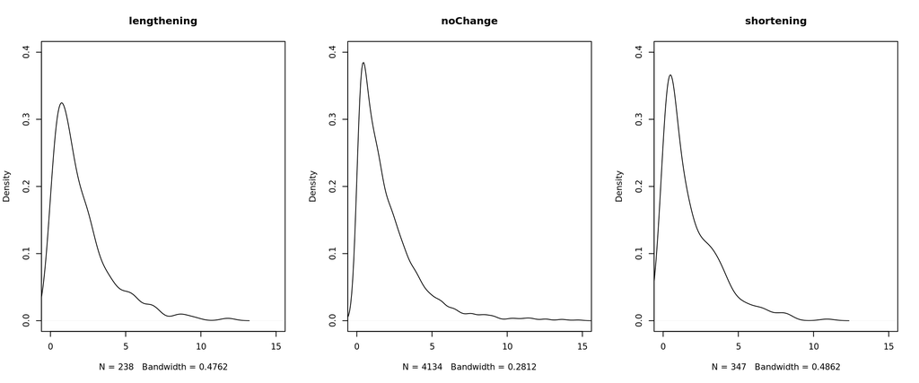

```r
par(mfrow=c(1 ,3))
plot(density(autr.df[autr.df$type=="lengthening",]$length), main='lengthening', ylim=c(0,0.4), xlim=c(0,15))
plot(density(autr.df[autr.df$type=="noChange",]$length), main='noChange', ylim=c(0,0.4), xlim=c(0,15))
plot(density(autr.df[autr.df$type=="shortening",]$length), main='shortening', ylim=c(0,0.4), xlim=c(0,15))
```

```r
ks.test(autr.df[autr.df$type=="lengthening",]$length, autr.df[autr.df$type=="noChange",]$length)
```

```
##
##  Two-sample Kolmogorov-Smirnov test
##
## data:  autr.df[autr.df$type == "lengthening", ]$length and autr.df[autr.df$type == "noChange", ]$length
## D = 0.044495, p-value = 0.7645
## alternative hypothesis: two-sided
```

```r
ks.test(autr.df[autr.df$type=="lengthening",]$length, autr.df[autr.df$type=="shortening",]$length)
```

```
##
##  Two-sample Kolmogorov-Smirnov test
##
## data:  autr.df[autr.df$type == "lengthening", ]$length and autr.df[autr.df$type == "shortening", ]$length
## D = 0.13345, p-value = 0.0131
## alternative hypothesis: two-sided
```

```r
ks.test(autr.df[autr.df$type=="shortening",]$length, autr.df[autr.df$type=="noChange",]$length)
```

```
##
##  Two-sample Kolmogorov-Smirnov test
##
## data:  autr.df[autr.df$type == "shortening", ]$length and autr.df[autr.df$type == "noChange", ]$length
## D = 0.11026, p-value = 0.000833
## alternative hypothesis: two-sided
```

```r
print(unique(as.character(type.list[['lengthening']]$Gene_Name))[1:20])
```

```
##  [1] "CYTH3"    "NISCH"    "MBTD1"    "LARS2"    "RB1CC1"   "FAS"
##  [7] "FBXO42"   "WDR37"    "THRAP3"   "ATP9A"    "CNN2"     "UHRF1BP1"
## [13] "TRAM2"    "MCM10"    "ERBB3"    "PITX1"    "GNB5"     "PTPN18"
## [19] "MARK2"    "TP73"
```

```r
print(unique(as.character(type.list[['shortening']]$Gene_Name))[1:20])
```

```
##  [1] "GCLC"    "FBXL3"   "SEC62"   "SEC63"   "VEZT"    "NUP160"  "FUT8"
##  [8] "RNF19A"  "BOD1L1"  "MAT2B"   "CDH1"    "MRPS10"  "RSF1"    "FAM120A"
## [15] "EPN3"    "ARID1B"  "ARID4B"  "SYNE2"   "KMT2C"   "CDK17"
```

#### Combind gene log fold change

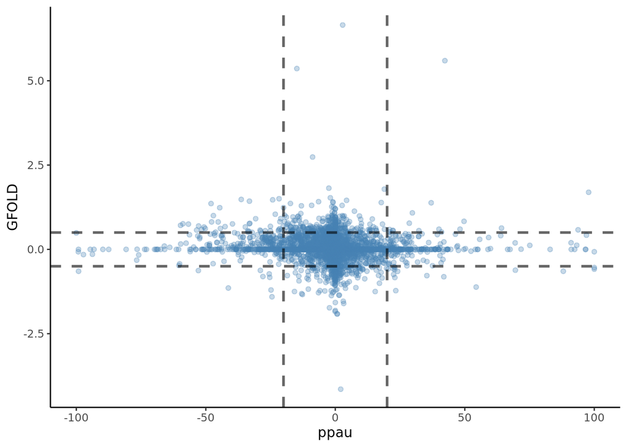

```r
gfold <- readRDS(file='~/APA/utr/gfold/gfold.res.rds')
colnames(gfold)[2] <- "Gene"

ppau.gf <- merge(ppas[,c('Gene', 'Gene_Name', 'ppau')], gfold[,c('Gene', 'GFOLD')], by='Gene')

# Scatter plot
line.df <- data.frame(v=c(-20, 20), h=c(-0.5, 0.5))

ggplot(ppau.gf, aes(x=ppau, y=GFOLD)) +
  geom_point(alpha=0.3, colour="steelblue") +
  geom_vline(aes(xintercept=v), line.df, lty=2, size=1, alpha=0.6) +
  geom_hline(aes(yintercept=h), line.df, lty=2, size=1, alpha=0.6) +
  theme_classic()
```

### Pathway analysis using goseq

```r
suppressPackageStartupMessages({
  library(goseq)
  library(GenomicFeatures)
})
# Conduct GOSeq
#head(supportedGenomes())
#pwf <- nullp(gene.reg, "hg38", "ensGene") #???

# delete duplicates & na in ppau.gf
ppau.gf <- ppau.gf[order(ppau.gf$Gene, -abs(ppau.gf$ppau), -abs(ppau.gf$GFOLD)),]
ppau.gf <- ppau.gf[!duplicated(ppau.gf$Gene),] #delete 15 rows
ppau.gf <- ppau.gf[!is.na(ppau.gf$ppau),] #delete 5 rows
ppau.gf$Gene <- factor(ppau.gf$Gene)
ppau.gf$Gene_Name <- factor(ppau.gf$Gene_Name)

# get gene length data by myself and mannualy provide to goseq
txdb <- makeTxDbFromGFF('~/APA/utr/transcriptome/Homo_sapiens.GRCh38.98.gtf.gz')
```

```
## Import genomic features from the file as a GRanges object ... OK
## Prepare the 'metadata' data frame ... OK
## Make the TxDb object ...
```

```
## OK
```

```r
exonBygene <- exonsBy(txdb, by="gene")
lengths <- sum(width(reduce(exonBygene)))
lengthsFilt <- lengths[names(lengths) %in% ppau.gf$Gene] # here I just annalyze the intersected genes of ppas & gfold


# goseq for different genes
getGOwall <- function(vec) {
  # function to get the gene lists of "numDFinCat" in GO.wall report
  getGeneLists <- function(pwf, goterms, genome, ids){
    gene2cat <- getgo(rownames(pwf), genome, ids)
    cat2gene <- split(rep(names(gene2cat), sapply(gene2cat, length)),
                      unlist(gene2cat, use.names = FALSE))
    out <- list()
    for(term in goterms){
      tmp <- pwf[cat2gene[[term]],]
      tmp <- rownames(tmp[tmp$DEgenes > 0, ])
      out[[term]] <- tmp
    }
    out
  }

  names(vec) <- ppau.gf$Gene
  print(table(vec))

  # goseq for GOBP
  suppressWarnings(pwf <- nullp(vec, "hg38", "ensGene", bias.data = lengthsFilt))
  GO.wall <- goseq(pwf, "hg38", "ensGene", test.cats = "GO:BP")
  go.list <- getGeneLists(pwf, GO.wall$category, "hg38", "ensGene")
  symbol.list <- lapply(go.list, function(x) as.character(ppau.gf[ppau.gf$Gene %in% x,]$Gene_Name))
  GO.wall$symbol <- sapply(GO.wall$category, function(x) paste0(symbol.list[[x]], collapse = ","))
  GO.wall
}


# up-regulated DEGs
uDEG.wall <- getGOwall(as.integer(ppau.gf$GFOLD > 0.1))
```

```
## vec
##    0    1
## 3302 1408
```

```
## Fetching GO annotations...
##
## For 82 genes, we could not find any categories. These genes will be excluded.
## To force their use, please run with use_genes_without_cat=TRUE (see documentation).
## This was the default behavior for version 1.15.1 and earlier.
## Calculating the p-values...
```

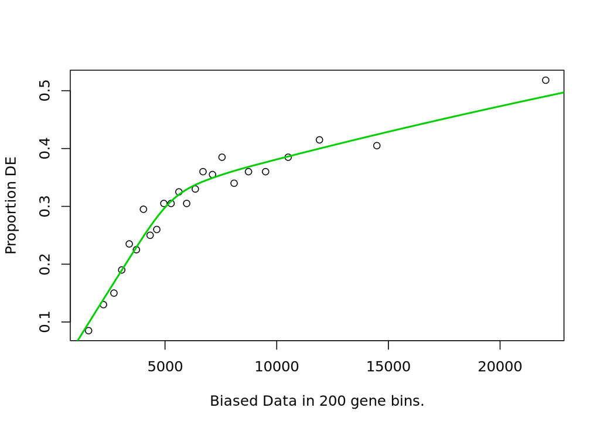

```r
# down-regulated DEGs
dDEG.wall <- getGOwall(as.integer(ppau.gf$GFOLD < -0.1))
```

```
## vec
##    0    1
## 3767  943
```

```
## Fetching GO annotations...
## For 82 genes, we could not find any categories. These genes will be excluded.
## To force their use, please run with use_genes_without_cat=TRUE (see documentation).
## This was the default behavior for version 1.15.1 and earlier.
## Calculating the p-values...
```

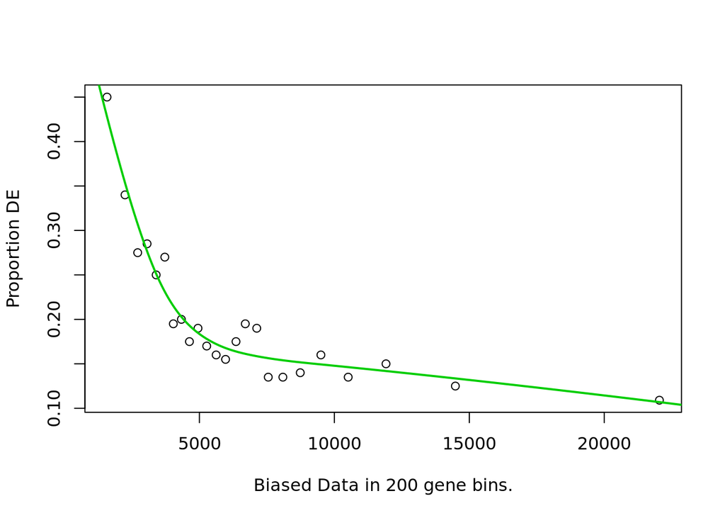

```r
# shortening genes
short.wall <- getGOwall(as.integer(ppau.gf$ppau < -20))
```

```
## vec
##    0    1
## 4363  347
```

```
## Fetching GO annotations...
## For 82 genes, we could not find any categories. These genes will be excluded.
## To force their use, please run with use_genes_without_cat=TRUE (see documentation).
## This was the default behavior for version 1.15.1 and earlier.
## Calculating the p-values...
```

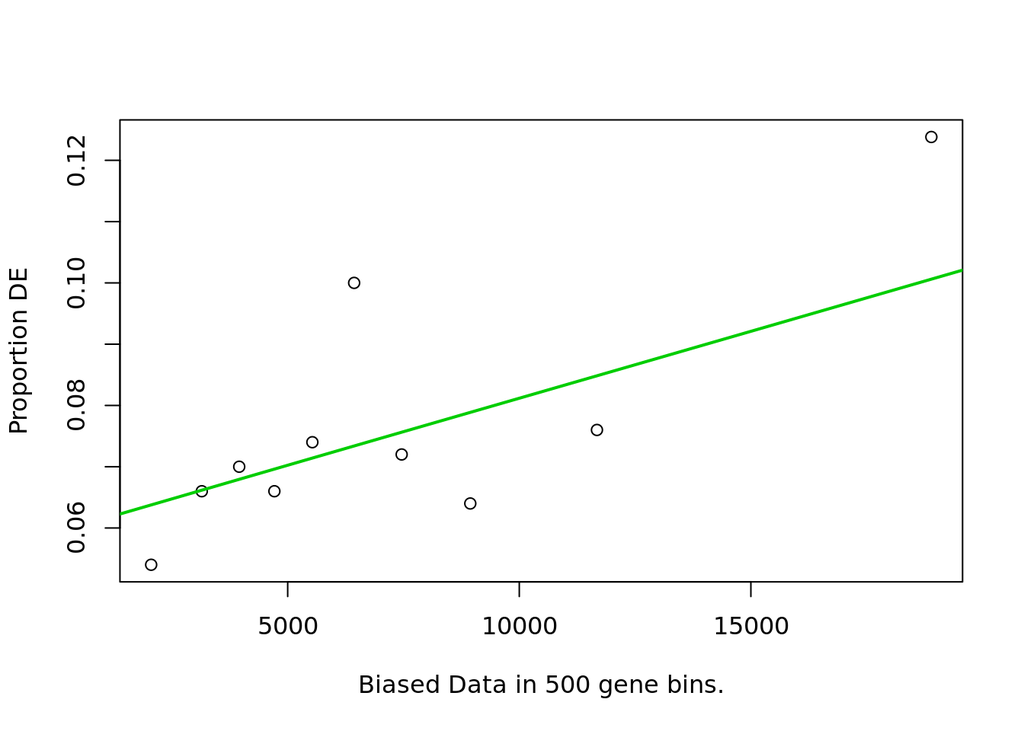

```r
# lengthening genes
long.wall <- getGOwall(as.integer(ppau.gf$ppau > 20))
```

```
## vec
##    0    1
## 4472  238
```

```
## Fetching GO annotations...
## For 82 genes, we could not find any categories. These genes will be excluded.
## To force their use, please run with use_genes_without_cat=TRUE (see documentation).
## This was the default behavior for version 1.15.1 and earlier.
## Calculating the p-values...
```

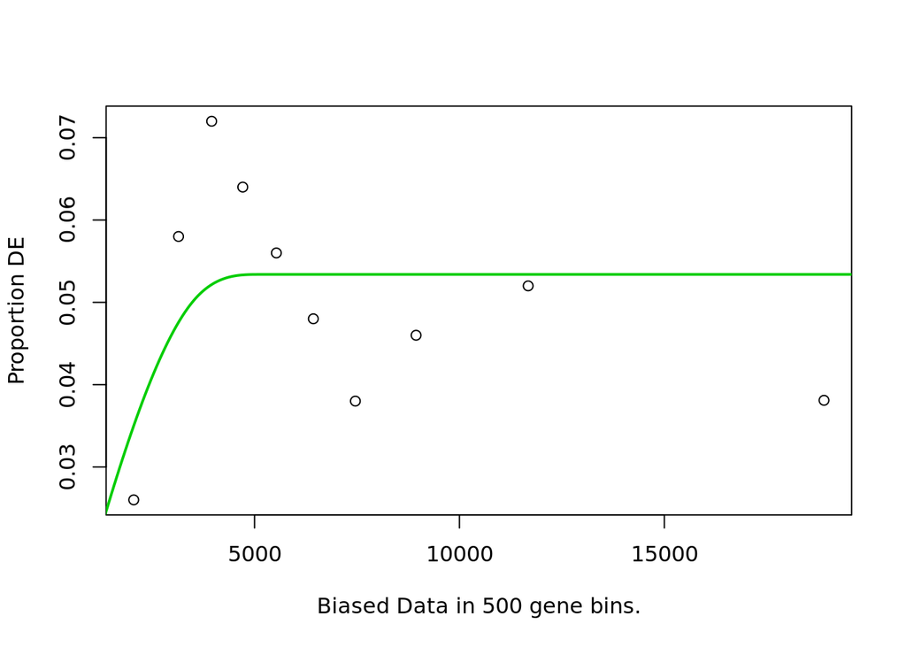

```r
# shortening & up-regulated
suDEG.wall <- getGOwall(as.integer(ppau.gf$GFOLD > 0.1 & ppau.gf$ppau < -20))
```

```
## vec
##    0    1
## 4562  148
```

```
## Fetching GO annotations...
## For 82 genes, we could not find any categories. These genes will be excluded.
## To force their use, please run with use_genes_without_cat=TRUE (see documentation).
## This was the default behavior for version 1.15.1 and earlier.
## Calculating the p-values...
```

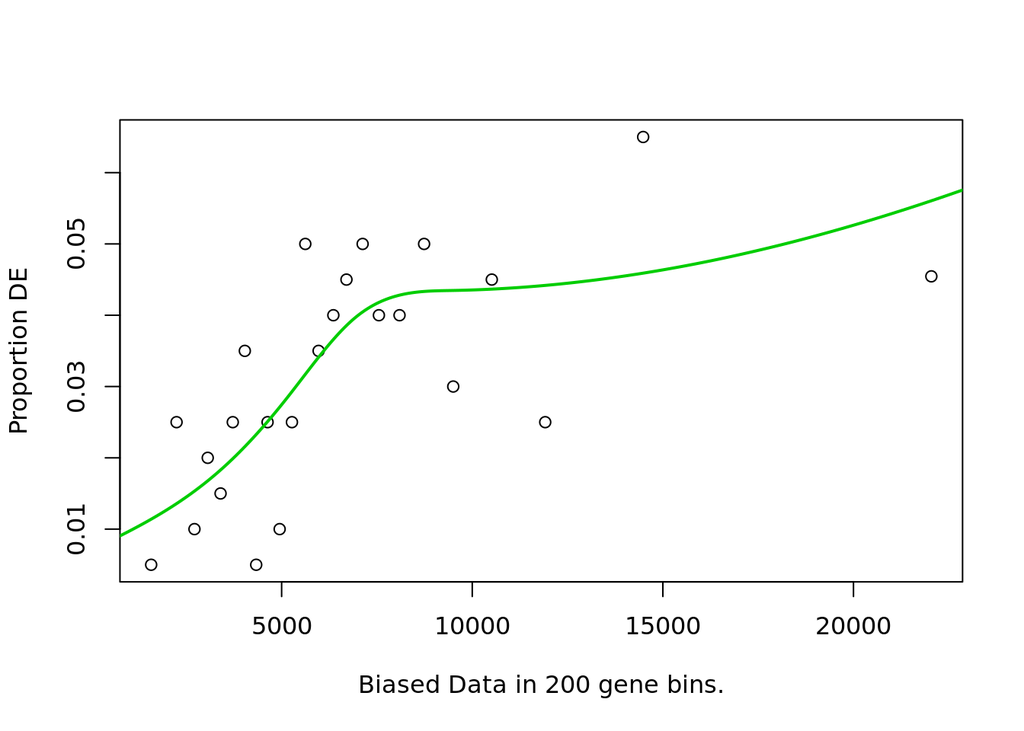

```r
head(suDEG.wall, 2)
```

```
##       category over_represented_pvalue under_represented_pvalue numDEInCat
## 773 GO:0003214            0.0003108978                0.9999966          3
## 734 GO:0003151            0.0003163404                0.9999660          6
##     numInCat                                 term ontology
## 773        4 cardiac left ventricle morphogenesis       BP
## 734       29          outflow tract morphogenesis       BP
##                                    symbol
## 773                     SMAD4,TGFBR2,RBPJ
## 734 SEMA3C,HIF1A,SMAD4,TGFBR2,CITED2,RBPJ
```

```r
# save goseq results
goseq.res <- list()
for (name in c('uDEG', 'dDEG', 'short', 'long', 'suDEG')) {
  goseq.res[[name]] <- get(paste0(name, '.wall'))
}
saveRDS(goseq.res, file='~/APA/utr/gfold/goseq.res.rds')
```

#### Visualize enriched pathways

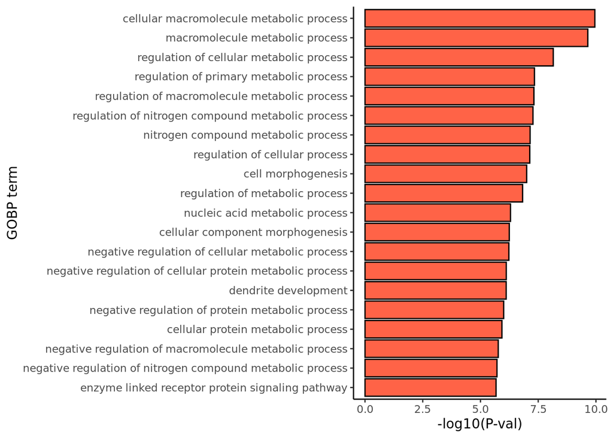

```r
drawPath <- function(wall, top.no, ccolor) {
  df <- wall[,c("over_represented_pvalue", "term")]
  df$logP <- -log10(df$over_represented_pvalue)
  pdf <- df[1:top.no, ]
  rownames(pdf) <- 1:nrow(pdf)
  pdf$term <- factor(pdf$term, levels = pdf$term)

  ggplot(pdf, aes(x=term, y=logP)) +
    geom_bar(stat = "identity", color="black", fill=ccolor) +
    coord_flip() + scale_x_discrete(limits=rev(levels(pdf$term))) +
    labs(y='-log10(P-val)', x='GOBP term') +
    theme_classic()
}

drawPath(uDEG.wall, 20, "tomato")
```

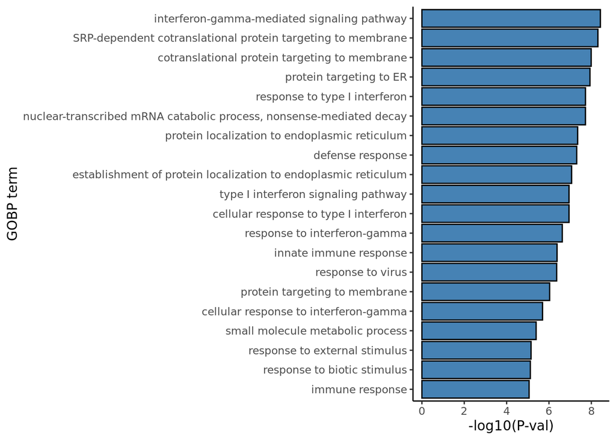

```r
drawPath(dDEG.wall, 20, "steelblue")
```

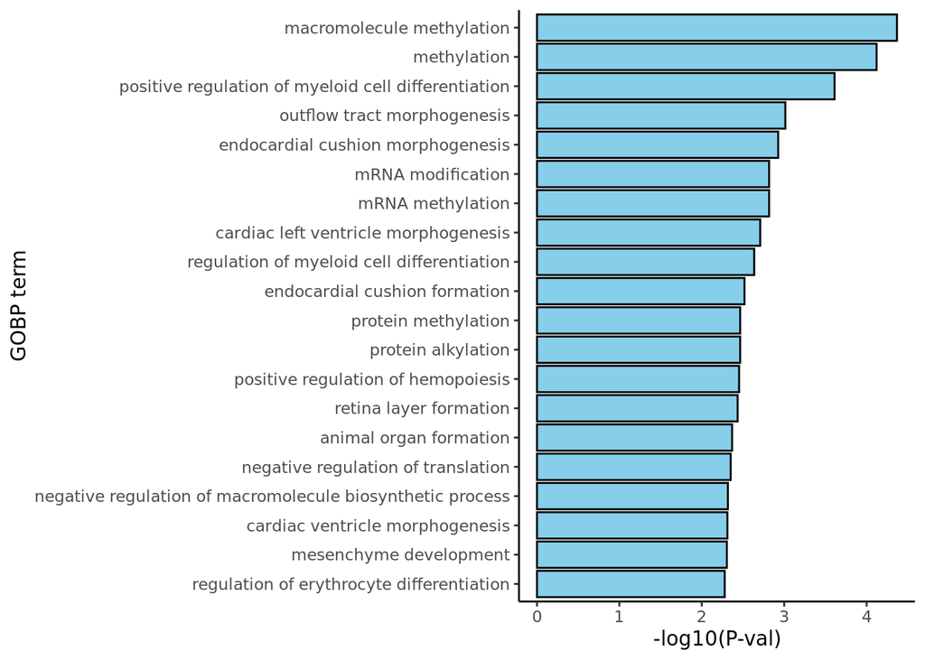

```r
drawPath(short.wall, 20, "skyblue")
```

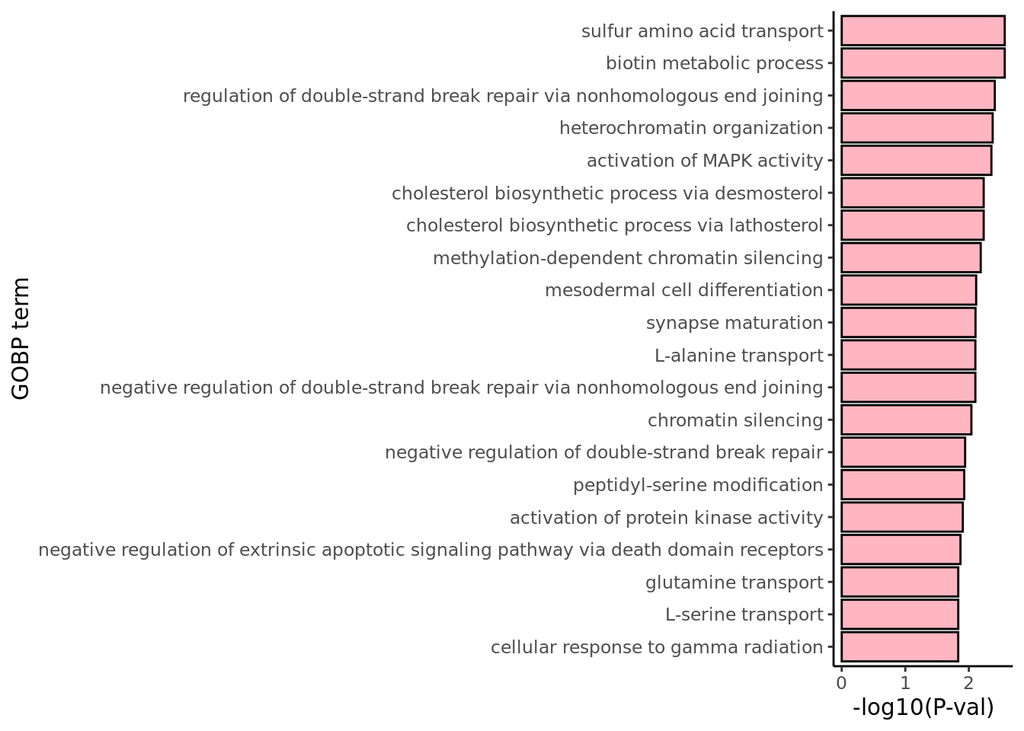

```r
drawPath(long.wall, 20, "lightpink")
```

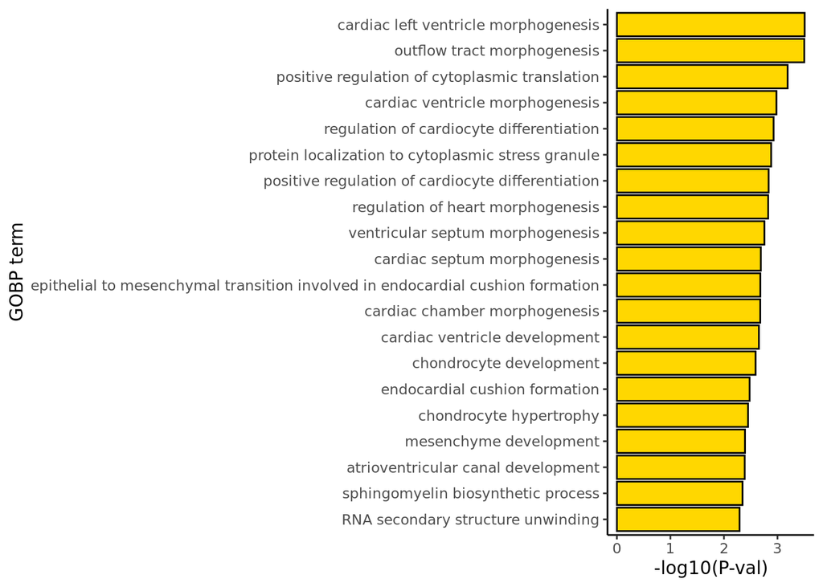

```r
drawPath(suDEG.wall, 20, "gold")
```